# Project 1

In Hughes et al. although rising global temperatures is shown to have risen over time, no statistical tests or form of temperature is used in their model for predicting the probability of severe coral bleaching events. To try and see if their model could be improved with more climate data, we used the ENSO dataset containing various climate measurements from 1950 to 2026, to see whether we could make an improved GLMM.

The following notebook contains the analyses on the climate data, the relationship between the climate data and bleaching data, and finally which model with which selected fixed effects (based on the climate data) performed best.

Right below we actually have why we decided to look at climate data (apart from the original paper only mentioning it). During very preliminary searches as to what we could look at, we found a figure that resembled figure 4 of the paper (which looks at severe and moderate bleaching events per year) - specifically the up and down nature because of the el Nino and la Nina cycles.

```r
#NO NEED TO RUN - this is the code for the enso data that gave the first clue that maybe we could use this data in our model

#this is so sick: https://semba-blog.netlify.app/01/20/2020/easy-access-of-el-nino-southern-oscillation-data-in-r/

# Load libraries
library(rsoi)
library(tidyverse)
library(cowplot)

# Download ENSO data including ONI (Oceanic Niño Index) and phases
enso = rsoi::download_enso() #this is not the actual data we used, it is just from this site

# View the first few rows
head(enso_data)
```

```
[1] "~/Desktop/dataset_enso_2026.csv"
```

```r
enso.plot = ggplot(data = enso, aes(x = Date, y = ONI, fill = phase))+
  geom_col()+
  # ggsci::scale_fill_jama() +
  scale_fill_manual(values = c("blue","green", "red"), name = "") +
  cowplot::theme_minimal_grid()+
  labs(x = "", y = "ENSO Index") +
  theme(legend.position = "top", panel.grid = element_line(linetype = "dotted"))

enso.plot %>%
  plotly::ggplotly() %>%
  plotly::layout(legend = list(orientation = "h", x = 0.4, y = 1.1))
```

[interactive chart not shown]

```r
NA
```

```r
#loading libraries and data

library(dplyr) #i love this one so much omg
library(readr)
library(tidyr)
library(ggplot2)
library(mgcv) #cannot remember what this is for tbh - gonna guess modelling (sorry some notes were written a while after the code was)
library(lme4) #glmm


bleached_data<- "~/Desktop/coral_data.xlsx" #this is the coral bleaching data that the researchers colelted
enso_data   <- "~/Desktop/dataset_enso_2026.csv" #this is the data we retrieved online

bleach <- read_excel(bleached_data)
enso_monthly <- read_csv(enso_data, show_col_types = FALSE)

glimpse(bleach)
```

```
Rows: 104
Columns: 50
$ `#`                                                  <dbl> 1, 2, 3, 4, 5, 6, 7, 8, 9, 10, 11, 12, 13, 14, 15, 16, 17, 18, 19…
$ Region                                               <chr> "Australasia", "Australasia", "Australasia", "Australasia", "Aust…
$ Location                                             <chr> "Australia, Coral Sea Northern", "Australia, Coral Sea Southern",…
$ Lat                                                  <chr> "16.5ºS", "20.0ºS", "19.5ºS", "11.5ºS", "23.5ºS", "21.5ºS", "31.5…
$ Long                                                 <chr> "149.8ºE", "153.0ºE", "148.5ºE", "145.3ºE", "150.1ºE", "115.4ºE",…
$ `Size (km²)`                                         <dbl> 1165, 231, 7735, 9319, 6872, 688, 12, NA, 120, 316, NA, 2, 385, 3…
$ `1980`                                               <chr> NA, NA, "M", "M", NA, NA, NA, NA, NA, NA, NA, NA, NA, NA, NA, NA,…
$ `1981`                                               <chr> NA, NA, NA, NA, NA, NA, NA, NA, NA, NA, NA, NA, NA, NA, NA, NA, N…
$ `1982`                                               <chr> NA, NA, NA, NA, NA, NA, NA, NA, NA, NA, NA, NA, NA, NA, NA, NA, N…
$ `1983`                                               <chr> NA, NA, "M", "M", NA, NA, NA, NA, NA, NA, NA, NA, NA, NA, NA, NA,…
$ `1984`                                               <chr> NA, NA, NA, NA, NA, NA, NA, NA, NA, NA, NA, NA, NA, NA, NA, NA, N…
$ `1985`                                               <chr> NA, NA, NA, NA, NA, NA, NA, NA, NA, NA, NA, NA, NA, NA, NA, NA, N…
$ `1986`                                               <chr> NA, NA, NA, NA, NA, NA, NA, NA, NA, NA, NA, NA, NA, NA, NA, NA, N…
```

[output cut: 37 more lines]

```r
glimpse(enso_monthly)
```

```
Rows: 924
Columns: 28
$ Date                               <chr> "1/1/1950", "2/1/1950", "3/1/1950", "4/1/1950", "5/1/1950", "6/1/1950", "7/1/1950",…
$ year                               <dbl> 1950, 1950, 1950, 1950, 1950, 1950, 1950, 1950, 1950, 1950, 1950, 1950, 1951, 1951,…
$ Month                              <chr> "JAN", "FEB", "MAR", "APR", "MAY", "JUN", "JUL", "AUG", "SEP", "OCT", "NOV", "DEC",…
$ Global_Temperature_Anomaly         <dbl> -0.26, -0.27, -0.07, -0.21, -0.11, -0.05, -0.08, -0.16, -0.11, -0.20, -0.34, -0.22,…
$ Nino_12_SST                        <dbl> 23.01, 24.32, 25.11, 23.63, 22.68, 21.33, 20.31, 20.12, 19.56, 19.99, 19.85, 21.72,…
$ `Nino_12 SST_Anomaly`              <dbl> -1.55, -1.78, -1.38, -1.90, -1.74, -1.79, -1.65, -0.88, -1.17, -1.02, -1.80, -1.09,…
$ Nino_3_SST                         <dbl> 23.56, 24.89, 26.36, 26.44, 25.69, 25.51, 24.91, 24.47, 24.01, 24.17, 23.86, 24.15,…
$ Nino_3_SST_Anomaly                 <dbl> -2.10, -1.52, -0.84, -1.14, -1.57, -1.11, -0.90, -0.65, -0.89, -0.81, -1.24, -1.08,…
$ Nino_34_SST                        <dbl> 24.55, 25.06, 25.87, 26.28, 26.18, 26.46, 26.29, 25.88, 25.74, 25.69, 25.47, 25.29,…
$ Nino_34_SST_Anomaly                <dbl> -1.99, -1.69, -1.42, -1.54, -1.75, -1.27, -1.01, -0.97, -0.98, -1.03, -1.23, -1.31,…
$ Nino_4_SST                         <dbl> 26.94, 26.67, 26.52, 26.90, 27.73, 28.13, 27.64, 27.54, 27.27, 27.13, 26.99, 27.14,…
$ Nino_4_SST_Anomaly                 <dbl> -1.38, -1.53, -1.80, -1.73, -1.18, -0.84, -1.26, -1.25, -1.49, -1.63, -1.70, -1.40,…
$ TNI                                <dbl> 0.624, 0.445, 0.382, 0.311, 0.124, 0.213, 0.293, 0.316, 0.564, 0.690, 0.993, 1.239,…
$ SOI                                <dbl> NA, NA, NA, NA, NA, NA, NA, NA, NA, NA, NA, NA, 2.5, 1.5, -0.2, -0.5, -1.1, 0.3, -1…
$ OLR                                <dbl> NA, NA, NA, NA, NA, NA, NA, NA, NA, NA, NA, NA, NA, NA, NA, NA, NA, NA, NA, NA, NA,…
$ PNA                                <dbl> -3.65, -1.69, -0.06, -0.23, -0.40, -1.99, -0.82, 0.79, -1.00, 0.70, -1.74, -0.28, -…
$ NOI                                <dbl> 2.644, 2.077, 3.091, 1.923, 2.211, 1.014, -0.336, -0.236, 0.170, -2.540, 0.483, -1.…
$ ENSO_Precipitation_Index           <dbl> NA, NA, NA, NA, NA, NA, NA, NA, NA, NA, NA, NA, NA, NA, NA, NA, NA, NA, NA, NA, NA,…
$ BEST                               <dbl> -0.67, -1.52, -1.37, -1.31, -1.26, -1.79, -1.72, -0.96, -0.92, -1.20, -1.08, -1.43,…
$ `Season_(2Month)`                  <chr> "DJ", "JF", "FM", "MA", "AM", "MJ", "JJ", "JA", "AS", "SO", "ON", "ND", "DJ", "JF",…
$ MEI_ext                            <dbl> -0.941, -1.131, -1.347, -1.377, -1.282, -1.232, -1.538, -1.797, -1.433, -1.030, -1.…
$ MEI_v2                             <dbl> NA, NA, NA, NA, NA, NA, NA, NA, NA, NA, NA, NA, NA, NA, NA, NA, NA, NA, NA, NA, NA,…
$ `Season_(3Month)`                  <chr> "DJF", "JFM", "FMA", "MAM", "AMJ", "MJJ", "JJA", "JAS", "ASO", "SON", "OND", "NDJ",…
$ ONI                                <dbl> -1.53, -1.34, -1.16, -1.18, -1.07, -0.85, -0.54, -0.42, -0.39, -0.44, -0.60, -0.80,…
$ RONI                               <dbl> -1.58, -1.26, -0.96, -1.10, -1.20, -0.68, -0.26, -0.29, -0.16, -0.21, -0.49, -0.52,…
$ `Season_(12Month)`                 <chr> "1950-1951", "1950-1951", "1950-1951", "1950-1951", "1950-1951", "1950-1951", "1950…
$ `ENSO_PhasenIntensity_(ONIbased)`  <chr> "N", "N", "N", "N", "N", "N", "N", "N", "N", "N", "N", "N", "ME", "ME", "ME", "ME",…
$ `ENSO_PhasenIntensity_(RONIbased)` <chr> "N", "N", "N", "N", "N", "N", "N", "N", "N", "N", "N", "N", "WE", "WE", "WE", "WE",…
```

So you can see from the glimpse (in the above cell) what these two data sets contain and now we are reformatting them a bit to contian only information we actually care about.

Somehting important to keep in mind already is that the researcher’s dataset is yearly data, but the ENSO data set has monthly values.

```r
# RESHAPING THE DATA (for simplicity)

#reshaping coral data (bleach) - long format

bleach_long <- bleach %>%
  filter(!is.na(`#`)) %>%
  select(
    location_id = '#', #qouations because otherwise would be a comment like this
    region = Region,
    locaiton_name = Location,
    '1980':'2016' #years we care about and need for long formatting
  ) %>%
  pivot_longer(
    cols = '1980':'2016',
    names_to = 'year',
    values_to = 'bleaching_status'
  ) %>%
  mutate( #we add columns now
    year = as.integer(year), #make sure it takes the number not a string
    #we want to assign binary values now - the funky part is that they had S M and NA because they ran two different analysis so depending on which analysis they assigned 1 and 0 to the diff variables. we are essentially doing the same but using different columns for this
     bleaching_status = ifelse(
      is.na(bleaching_status),
      "None",
      bleaching_status
    ), # so in this bleaching status column all NA values are def None
    severe = ifelse(
      bleaching_status == "S",
      1L, #S will always be 1 no matter what analysis
      0L
    ),
    any_bleach = ifelse(
      bleaching_status %in% c("S", "M"),
      1L, #this is another analysis where we look at cumulative bleaching essentially (any_bleach) so both S and M are 1
      0L
    ),
    t = year - 1980 #we add a variable that represents the same one the researchers used (years since 1980)
  )

glimpse(bleach_long)
```

```
Rows: 3,700
Columns: 8
$ location_id      <dbl> 1, 1, 1, 1, 1, 1, 1, 1, 1, 1, 1, 1, 1, 1, 1, 1, 1, 1, 1, 1, 1, 1, 1, 1, 1, 1, 1, 1, 1, 1, 1, 1, 1, 1,…
$ region           <chr> "Australasia", "Australasia", "Australasia", "Australasia", "Australasia", "Australasia", "Australasi…
$ locaiton_name    <chr> "Australia, Coral Sea Northern", "Australia, Coral Sea Northern", "Australia, Coral Sea Northern", "A…
$ year             <int> 1980, 1981, 1982, 1983, 1984, 1985, 1986, 1987, 1988, 1989, 1990, 1991, 1992, 1993, 1994, 1995, 1996,…
$ bleaching_status <chr> "None", "None", "None", "None", "None", "None", "None", "None", "None", "None", "None", "None", "None…
$ severe           <int> 0, 0, 0, 0, 0, 0, 0, 0, 0, 0, 0, 0, 0, 0, 0, 0, 0, 0, 1, 0, 0, 0, 1, 0, 0, 0, 0, 0, 0, 0, 0, 0, 0, 0,…
$ any_bleach       <int> 0, 0, 0, 0, 0, 0, 0, 0, 0, 0, 0, 0, 0, 0, 0, 0, 0, 0, 1, 0, 0, 0, 1, 0, 1, 0, 0, 0, 0, 0, 0, 0, 0, 0,…
$ t                <dbl> 0, 1, 2, 3, 4, 5, 6, 7, 8, 9, 10, 11, 12, 13, 14, 15, 16, 17, 18, 19, 20, 21, 22, 23, 24, 25, 26, 27,…
```

```r
table(bleach_long$bleaching_status)
```

```
   M None    S
 309 3092  299
```

```r
table(bleach_long$severe)
```

```
   0    1
3401  299
```

```r
n_distinct(bleach_long$location_id)
```

```
[1] 100
```

```r
n_distinct(bleach_long$year)
```

```
[1] 37
```

```r
nrow(bleach_long)
```

```
[1] 3700
```

```r
#checking because there was an error initially
bleach %>%
  filter(is.na(`#`)) %>%
  select(`#`, Region, Location)
```

| # | Region | Location |
| --- | --- | --- |
| NA | NA | NA |
| NA | NA | Severe (S) records per year |
| NA | NA | Minor-moderate (M) records per year |
| NA | NA | Total records per year |

```r
bleach %>%
  count(`#`) %>%
  filter(n > 1 | is.na(`#`))
```

| # | n |
| --- | --- |
| NA | 4 |

```r
#enso data formatting now
#the reason why we are looking at this data is because of some similar trends in the figures of severe and moderate bleaching across the regions in the paper and an enso data graph that was found in a very prelinary analysis of stuff mentioned in the paper (the cell with the code is above - it is not my code and completely copied from the source provided !! the cell doesn't need to be run)

#not so subtle foreshadowing - we're looking at this data (from an actual dataset and not just a generated plot) to see whether we could model bleaching frequency better since we see ups and downs in the climate data - the researchers look only at time (which makes sense because they tell us how temperature is going up over time and how el nino and la nina are kind of converging) so we want to see whether we can actually correlate it to temperature (initially the plan was to see whether we could actually look at regional enso data to match the latitudes and longitudes with certain enso collections but unfortuantely that's not quite the case so we went with focusing on nino3.4 since that is the main one used)
#https://www.ncei.noaa.gov/access/monitoring/enso/sst/

#first we take the years we actually care about - it'll be easier to fileter fro the start
enso_monthly <- enso_monthly %>%
  filter(year >= 1980, year <= 2016)

#so now we choose what variables we care about - for the sake of the graph it will be ONI data. but for later stuff we want the 3.4 data
enso_monthly <- enso_monthly %>%
  mutate( #new column
    enso_phase = case_when(
      `ENSO_PhasenIntensity_(ONIbased)` %in%
        c('VSE', 'SE', 'ME', 'WE') ~ 'El Nino',
      `ENSO_PhasenIntensity_(ONIbased)` %in%
        c('SL', 'ML', 'WL') ~ 'La Nina',
      `ENSO_PhasenIntensity_(ONIbased)` %in%
        c('N') ~ 'Neutral',
      TRUE ~ NA_character_
    ))
#so i literally took their classifications (which is ONi-based) and said if tey were nino, nina, or neutral.

glimpse(enso_monthly)
```

```
Rows: 444
Columns: 29
$ Date                               <chr> "1/1/1980", "2/1/1980", "3/1/1980", "4/1/1980", "5/1/1980", "6/1/1980", "7/1/1980",…
$ year                               <dbl> 1980, 1980, 1980, 1980, 1980, 1980, 1980, 1980, 1980, 1980, 1980, 1980, 1981, 1981,…
$ Month                              <chr> "JAN", "FEB", "MAR", "APR", "MAY", "JUN", "JUL", "AUG", "SEP", "OCT", "NOV", "DEC",…
$ Global_Temperature_Anomaly         <dbl> 0.29, 0.39, 0.29, 0.30, 0.35, 0.20, 0.22, 0.18, 0.21, 0.13, 0.30, 0.21, 0.53, 0.42,…
$ Nino_12_SST                        <dbl> 24.32, 25.68, 26.48, 25.54, 23.98, 22.76, 21.12, 20.52, 20.43, 20.52, 21.24, 22.41,…
$ `Nino_12 SST_Anomaly`              <dbl> -0.25, -0.42, -0.01, 0.00, -0.43, -0.36, -0.84, -0.48, -0.30, -0.50, -0.41, -0.40, …
$ Nino_3_SST                         <dbl> 26.04, 26.44, 27.03, 27.38, 27.10, 26.70, 25.57, 24.78, 24.72, 24.56, 25.00, 25.23,…
$ Nino_3_SST_Anomaly                 <dbl> 0.38, 0.03, -0.18, -0.20, -0.15, 0.08, -0.23, -0.34, -0.18, -0.42, -0.10, 0.01, -0.…
$ Nino_34_SST                        <dbl> 27.08, 26.97, 27.31, 27.75, 28.01, 27.94, 27.23, 26.48, 26.44, 26.46, 26.60, 26.65,…
$ Nino_34_SST_Anomaly                <dbl> 0.54, 0.22, 0.03, -0.07, 0.08, 0.21, -0.06, -0.38, -0.28, -0.26, -0.10, 0.05, -0.36…
$ Nino_4_SST                         <dbl> 28.69, 28.56, 28.51, 28.76, 29.18, 29.13, 28.92, 28.50, 28.49, 28.74, 28.68, 28.51,…
$ Nino_4_SST_Anomaly                 <dbl> 0.37, 0.36, 0.19, 0.14, 0.26, 0.16, 0.02, -0.29, -0.27, -0.02, -0.02, -0.03, -0.13,…
$ TNI                                <dbl> -1.073, -1.201, -1.040, -0.996, -1.039, -1.039, -1.018, -1.135, -1.284, -1.291, -1.…
```

[output cut: 16 more lines]

```r
#ok now we want yearly data b/c the paper's data is by year - sorry this cell is getting long

#we are also adding a few other variables (min, median, max....) since we decided it might be best to try out a range of possibilities - this is especially because our dataset had monthly temperatures and although mean is a good start to observe, temperature fluctations and weather can shift drastically across the months and potentially get hidden in the mean. so we're seeing if there are possibly better metrics that could display the extreme events we care about (but not to a a point where we are biased)

enso_yearly <- enso_monthly %>%
  group_by(year) %>%
  summarise(
    nino34_sst_mean = #we want to see the annual mean for the temperature data (in C)
      mean(Nino_34_SST, na.rm = TRUE),
    nino34_anom_mean = #this is the mean of the anomalies (we care about this for the model since we are relying on those)
      mean(Nino_34_SST_Anomaly, na.rm = TRUE),
    nino34_anom_max = #we're taking highest and lowest values too for later analysis - good to know max and min especially for our model
      max(Nino_34_SST_Anomaly, na.rm = TRUE),
    nino34_anom_min =
      min(Nino_34_SST_Anomaly, na.rm = TRUE),
    oni_mean = #oni is based on 3.4 data but slightly different as it uses a different way of caluclating anomalies (different amount of time - monthwise)
      mean(ONI, na.rm = TRUE),
    oni_max =
      max(ONI, na.rm = TRUE),
    oni_min =
      min(ONI, na.rm = TRUE),
    global_temp_anom_mean = #we're also taking global temp mean because it can help show us differences in nino/nina anomalies
      mean(Global_Temperature_Anomaly, na.rm = TRUE),

    .groups = "drop"
  )

glimpse(enso_yearly)
```

```
Rows: 37
Columns: 9
$ year                  <dbl> 1980, 1981, 1982, 1983, 1984, 1985, 1986, 1987, 1988, 1989, 1990, 1991, 1992, 1993, 1994, 1995, …
$ nino34_sst_mean       <dbl> 27.07667, 26.62250, 27.91083, 27.38583, 26.41417, 26.32417, 27.13917, 28.17250, 26.07917, 26.281…
$ nino34_anom_mean      <dbl> -0.001666667, -0.455833333, 0.831666667, 0.306666667, -0.664166667, -0.755000000, 0.060000000, 1…
$ nino34_anom_max       <dbl> 0.54, -0.19, 2.20, 2.35, -0.19, -0.37, 1.12, 1.65, 0.90, -0.13, 0.35, 1.69, 1.84, 0.78, 1.25, 1.…
$ nino34_anom_min       <dbl> -0.38, -0.64, -0.17, -1.29, -1.34, -1.18, -0.71, 0.58, -2.05, -1.97, -0.08, 0.03, -0.30, 0.00, 0…
$ oni_mean              <dbl> 0.25333333, -0.26833333, 0.99000000, 0.48000000, -0.50583333, -0.59833333, 0.25333333, 1.2766666…
$ oni_max               <dbl> 0.59, -0.08, 2.23, 2.18, -0.16, -0.27, 1.22, 1.70, 0.81, -0.05, 0.41, 1.53, 1.71, 0.70, 1.09, 0.…
$ oni_min               <dbl> -0.07, -0.50, -0.05, -1.00, -1.14, -1.04, -0.49, 0.95, -1.85, -1.69, 0.14, 0.22, -0.28, 0.04, 0.…
$ global_temp_anom_mean <dbl> 0.2558333, 0.3225000, 0.1391667, 0.3150000, 0.1558333, 0.1175000, 0.1800000, 0.3216667, 0.389166…
```

```r
# we want to see if we can replicate that graph we saw initially because we don't know if we're working with the same dataset and maybe this is something completely different

#actual plotting of the enso data that gives us a hint that we could actually use this data for a model
#shoutout dpylr again it's amazing

enso_yearly_phase <- enso_monthly %>%
  filter(!is.na(enso_phase)) %>%
  count(
    year,
    enso_phase,
    name = "months"
  ) %>%
  group_by(year) %>%
  slice_max(
    months,
    n = 1,
    with_ties = FALSE
  ) %>%
  ungroup() %>%
  select(
    year,
    dominant_enso_phase = enso_phase
  )

enso_yearly <- enso_yearly %>%
  left_join(
    enso_yearly_phase,
    by = "year"
  )

glimpse(enso_yearly)
```

```
Rows: 37
Columns: 10
$ year                  <dbl> 1980, 1981, 1982, 1983, 1984, 1985, 1986, 1987, 1988, 1989, 1990, 1991, 1992, 1993, 1994, 1995, …
$ nino34_sst_mean       <dbl> 27.07667, 26.62250, 27.91083, 27.38583, 26.41417, 26.32417, 27.13917, 28.17250, 26.07917, 26.281…
$ nino34_anom_mean      <dbl> -0.001666667, -0.455833333, 0.831666667, 0.306666667, -0.664166667, -0.755000000, 0.060000000, 1…
$ nino34_anom_max       <dbl> 0.54, -0.19, 2.20, 2.35, -0.19, -0.37, 1.12, 1.65, 0.90, -0.13, 0.35, 1.69, 1.84, 0.78, 1.25, 1.…
$ nino34_anom_min       <dbl> -0.38, -0.64, -0.17, -1.29, -1.34, -1.18, -0.71, 0.58, -2.05, -1.97, -0.08, 0.03, -0.30, 0.00, 0…
$ oni_mean              <dbl> 0.25333333, -0.26833333, 0.99000000, 0.48000000, -0.50583333, -0.59833333, 0.25333333, 1.2766666…
$ oni_max               <dbl> 0.59, -0.08, 2.23, 2.18, -0.16, -0.27, 1.22, 1.70, 0.81, -0.05, 0.41, 1.53, 1.71, 0.70, 1.09, 0.…
$ oni_min               <dbl> -0.07, -0.50, -0.05, -1.00, -1.14, -1.04, -0.49, 0.95, -1.85, -1.69, 0.14, 0.22, -0.28, 0.04, 0.…
$ global_temp_anom_mean <dbl> 0.2558333, 0.3225000, 0.1391667, 0.3150000, 0.1558333, 0.1175000, 0.1800000, 0.3216667, 0.389166…
$ dominant_enso_phase   <chr> "Neutral", "Neutral", "El Nino", "La Nina", "La Nina", "Neutral", "El Nino", "El Nino", "La Nina…
```

```r
table(enso_yearly$dominant_enso_phase)
```

```
El Nino La Nina Neutral
     12      13      12
```

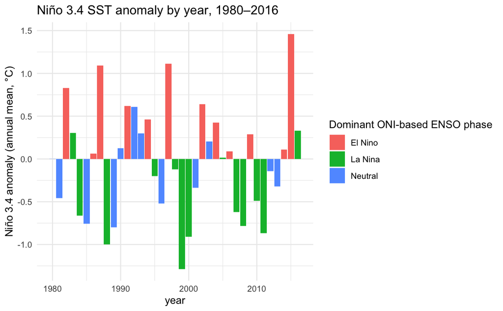

```r
#plotting
ggplot(
  enso_yearly,
  aes(
    x = year,
    y = nino34_anom_mean,
    fill = dominant_enso_phase
  )
) +
  geom_col() +
  labs(
    title = "Niño 3.4 SST anomaly by year, 1980–2016",
    x = "year",
    y = "Niño 3.4 anomaly (annual mean, °C)",
    fill = "Dominant ONI-based ENSO phase"
  ) +
  theme_minimal()
```

```r
#lo and behold we have some ups and downs that "coincidentally" match with the ups and downs we see in figure 4
#so now we want to see if there is an actual correlation between the anomaly data and the bleaching frequency data - because personally i did not quite like that they showed rising temperatures and were like yeah years since 1980 is good enough to show that temperature is rising but we won't actually use temperature or the enso index in our model

#they aren't wrong though and we can see a plot that shows this too - nest cell (because its not as directly important to the model we want to make)
```

[output not shown]

ok so we can see our dataset is actually showing similar patterns to what we saw before and still corresponds with the paper’s figures too (yay).

now we want to see which of the variables we pulled might actually correlated with the data